# DoDo пицца

```python
import pandas as pd
import matplotlib
import matplotlib.pyplot as plt
import time
from ipykernel import kernelapp as app
%matplotlib inline
matplotlib.style.use('ggplot')
```

## Стандартный анализ имеющегося датасета

```python
train = pd.read_csv("train.csv")
```

```python
train.head()
```

|  | date | city | orders |
| --- | --- | --- | --- |
| 0 | 09.10.11 | Сыктывкар-1 | 1 |
| 1 | 15.11.11 | Сыктывкар-1 | 1 |
| 2 | 18.12.11 | Сыктывкар-1 | 100 |
| 3 | 25.12.11 | Сыктывкар-1 | 122 |
| 4 | 28.12.11 | Сыктывкар-1 | 128 |

```python
(maximal, mean, median) = map(int, (train.orders.max(),train.orders.mean(), train.orders.median()))
print("MAX:%s\nMEAN:%s\nMEDIAN:%s"%(maximal, mean, median))
```

```
MAX:2044
MEAN:106
MEDIAN:87
```

## Подготовка датасета

```python
#Обьединим все заведения в городах в один город и преобразуем дату
train["city"] = train["city"].apply(func = lambda s: "".join(s.split("-")[0:-1]))
train["date"] = pd.to_datetime(train["date"])
train.head()
```

|  | date | city | orders |
| --- | --- | --- | --- |
| 0 | 2011-09-10 | Сыктывкар | 1 |
| 1 | 2011-11-15 | Сыктывкар | 1 |
| 2 | 2011-12-18 | Сыктывкар | 100 |
| 3 | 2011-12-25 | Сыктывкар | 122 |
| 4 | 2011-12-28 | Сыктывкар | 128 |

# Начало анализа

### Предположение первое: праздники

Поскольку в нашем мире имеют место быть праздники, то попробуем проверить теорию и отсортировать датасет по продажам и просмотреть дату

```python
#В итоге мы видим, что чаще всего покуапают в новый год
train.groupby("city").max().sort_values(by = "orders", ascending=False).head()
```

| city | date | orders |
| --- | --- | --- |
| Сыктывкар | 2016-12-10 | 2044 |
| Калуга | 2016-12-10 | 1472 |
| Ухта | 2016-12-10 | 1224 |
| Смоленск | 2016-12-10 | 1201 |
| Таганрог | 2016-12-10 | 1105 |

### Анализ 2015 года

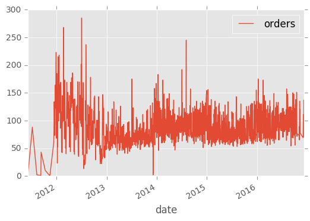

```python
cities_statistic = train.groupby("date").median()
cities_statistic.plot()
```

График получился очень большим, поэтому выделим cтатистику за 2015 год

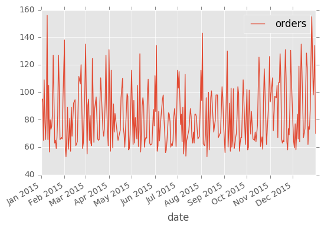

```python
cities_statistic_2015 = train.loc[train.date.dt.year == 2015].groupby("date").median()
cities_statistic_2015.plot()
```

На графике уже видны значительные пики. Давайте выделим те значения, которые значительно отличаются от медианы и отсортируем их.

```python
holydays_2015 = cities_statistic_2015.loc[cities_statistic_2015.orders >= median+42]
holydays_2015
```

| date | orders |
| --- | --- |
| 2015-01-09 | 156.0 |
| 2015-02-01 | 138.0 |
| 2015-03-01 | 135.0 |
| 2015-04-01 | 131.0 |
| 2015-06-03 | 134.0 |
| 2015-08-03 | 143.0 |
| 2015-09-05 | 130.0 |
| 2015-11-21 | 131.0 |
| 2015-11-28 | 130.5 |
| 2015-12-12 | 135.0 |
| 2015-12-26 | 155.0 |
| 2015-12-30 | 134.0 |

Хмм, похоже мы нашли следующую закономерность:

- Значительно продажи усиливаются в новогоднее время, а именно с конца ноября (21-28), до конца новогодних каникул (9 января)
- Помимо нового года праздники отсутсвуют
- Однако, можно заметить, что продажи резко возрастают в первых числах месяца (3-5), связано это в первую очередь с выдачей зарплаты.

Чтобы убедится, что более нет значимых дат для Россиян в которые они начинают скупать пиццу, давайте просмотрим статистику за 2014, 2013 и 2016 год

### Анализ 2014 года

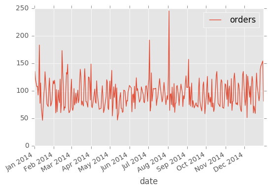

```python
cities_statistic_2014 = train.loc[train.date.dt.year == 2014].groupby("date").median()
cities_statistic_2014.plot()
```

Здесь мы так же, видим ежемесячное повышение продаж, но так же заметно огромное колличество шума ввиде множества других пиков. Давайте взглянем на них.

```python
holydays_2014 = cities_statistic_2014.loc[cities_statistic_2014.orders >= median+50]
holydays_2014
```

| date | orders |
| --- | --- |
| 2014-01-09 | 183.0 |
| 2014-02-14 | 173.0 |
| 2014-02-23 | 148.0 |
| 2014-03-15 | 139.0 |
| 2014-03-22 | 140.0 |
| 2014-04-01 | 148.5 |
| 2014-05-04 | 137.0 |
| 2014-07-03 | 192.0 |
| 2014-08-03 | 245.0 |
| 2014-09-03 | 157.0 |
| 2014-12-26 | 139.0 |
| 2014-12-27 | 145.0 |
| 2014-12-30 | 154.0 |

Теперь просмотрим 2013 год и удостоверимся в нашей теории.

### Анализ 2013 года

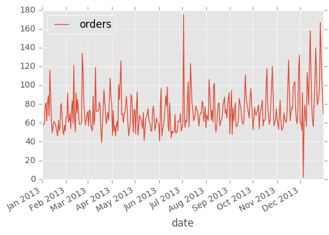

```python
cities_statistic_2013 = train.loc[train.date.dt.year == 2013].groupby("date").median()
cities_statistic_2013.plot()
```

Замечаем, что в принципе средние закупки ниже чем в 2014 году, скоре всего в это время пицца еще не так сильно вошла в обиход людей. Однако активность покупателей остается высокой.

```python
holydays_2013 = cities_statistic_2013.loc[cities_statistic_2013.orders >= median+35]
holydays_2013
```

| date | orders |
| --- | --- |
| 2013-02-22 | 134.0 |
| 2013-04-13 | 126.0 |
| 2013-07-03 | 175.0 |
| 2013-07-12 | 123.0 |
| 2013-11-16 | 127.0 |
| 2013-11-30 | 132.0 |
| 2013-12-13 | 125.0 |
| 2013-12-14 | 158.0 |
| 2013-12-21 | 140.0 |
| 2013-12-27 | 167.0 |

Здесь мы замечаем, что тенденция закупки в начале месяца отсутсвует. Причина описывалась ранее - пицца не вошла в обиход. Список праздников остается примерно таким же.

Из этого мы выяснили, что за 3 года отношение к пицце как к блюду изменилось, и для установки точных *пиков* активностии на текущий момент стоит провести анализ текущего года

### Анализ 2016 года

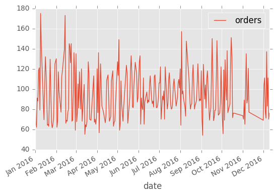

```python
cities_statistic_2016 = train.loc[train.date.dt.year == 2016].groupby("date").median()
cities_statistic_2016.plot()
```

```python
holydays_2016 = cities_statistic_2016.loc[cities_statistic_2016.orders >= median+50]
holydays_2016
```

| date | orders |
| --- | --- |
| 2016-01-09 | 175.0 |
| 2016-01-10 | 145.0 |
| 2016-02-13 | 140.0 |
| 2016-02-14 | 173.0 |
| 2016-02-20 | 145.0 |
| 2016-02-21 | 142.0 |
| 2016-02-23 | 145.0 |
| 2016-05-03 | 149.0 |
| 2016-08-03 | 157.0 |
| 2016-08-10 | 147.5 |
| 2016-09-17 | 150.0 |
| 2016-09-24 | 148.0 |
| 2016-10-09 | 138.0 |
| 2016-10-15 | 151.0 |
| 2016-12-06 | 137.0 |

Как видим, статистика несколько лучше чем в 2015 году (экономическая обстановка устоялась). Поэтому кроме ежемесячных закупок присутствуют и праздники:

- Новый год
- День святого валентина
- 23 февраля

### Итог

В связи с этим мы добавим в датасет следующие параметры:

- Булевый параметр указывающий, то первые ли сейчас числа месяца
- Булевый параметр указывающий, сейчас ли праздничный день
- Числовой параметр указывающий растояние до нового года (больше нуля, когда дата находится в диапазоне от 28 ноября по 9 января)